# pyMódulo 08

Curso IE0217 Estructuras abstractas y algoritmos para ingeniería - UCR

Profesor Freddy Rojas Ch.

1/29/2021

# Lenguaje Python 3 Módulo 8

En este módulo 8 de Python 3 se van a realizar el estudio de casos mediante ejemplos.

## Ejemplo 1.

Se necesita diseñar un sistema de *Cierre de facturación* utilizando Python3, bajo los siguientes requisitos,considerando el uso de *class* en Python:

#### Compra

Una compra tiene la siguiente información:

1. Codigo
2. Descripcion
3. MontoCompra

#### Cliente

Un cliente tiene los siguientes datos:

1. NombreCliente
2. DireccionCliente
3. Una lista de compras.

#### Factura

La factura debe contar con la siguiente información:

1. Código
2. Cliente
3. Monto: El monto total corresponde con el total que debe pagarse según la siguiente fórmula:: *TotalPagar = MontoTotal + PorcentajeImpuesto ∗ MontoTotal*
4. PorcentajeImpuesto
5. Una lista de compras

Existen dos tipos de factura: crédito y contado.

#### Factura de crédito

Una factura de crédito es una factura que contiene además de los campos de una factura (base) un plazo de credito dado en meses.

#### Factura de contado

Una factura de contado es una factura que contiene además de la factura (base) un porcentaje de descuento de modo que el nuevo total a pagar está dado por: *TotalPagar = MontoTotal + PorcentajeImpuesto ∗ Monto − TotalPorcentaje − Descuento ∗ MontoTotal*

### Requisitos de implementación

Se desarrollará una implementación que contiene varios métodos que permiten:

1)Modificar los datos.

2. Obtener los datos
3. Un constructor.
4. Un método para capturar (por teclado) la información factura
5. Un método para visualizar (a consola) la tipoe str (self) que debe considerar la impresión de todos los datos en forma polimórfica para cubrir con un método común la entrada y salida de los datos de facturas de contado y de crédito.
6. Debe desarrollarse un menú de observarción para ingresar los datos.

## Solución.

Para establecer la jerarquía de clases a utilizar como solución se va a utilizar el siguiente diagrama *UML*

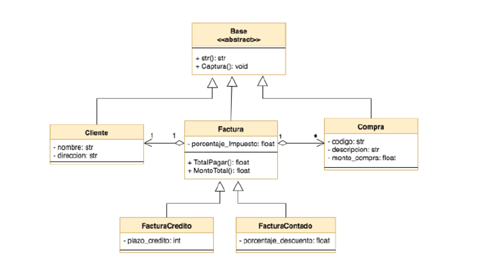

Diagrama UML que describe solución para sistema para cierre de facturación

##Base

```python
# Clases base abstractas
import sys
from abc import  ABCMeta, abstractmethod

## Clase Abstracta, ABC Class
class Base(metaclass=ABCMeta):

    @abstractmethod
    def __str__(self):
        pass

    @abstractmethod
    def Captura(self):
        pass


class BaseIO(object):
    def Input(self, info=""):
        return input(info)
```

## Declaración de clases para la implementación

### Clase Compra

```python
# Clase Compra
############################
class Compra(Base, BaseIO):
    def __init__(self) :
        self.__Codigo = 0
        self.__Descripcion = ""
        self.__MontoCompras = 0.0

    @property
    def Codigo(self) :
        return(self.__Codigo)

    @Codigo.setter
    def Codigo(self, codigo) :
        self.__Codigo = codigo

    @property
    def Descripcion(self) :
        return (self.__Descripcion)

    @Descripcion.setter
    def Descripcion(self, descripcion) :
        self.__Descripcion = descripcion

    @property
    def MontoCompras(self) :
        return(self.__MontoCompras)

    @MontoCompras.setter
    def MontoCompras(self, monto_compras) :
        self.__MontoCompras = monto_compras

    def __str__(self):
        return ("Código de compra: %s\nDescripción de compra %s\nMontoCompra %.2f\n"
                 % (self.__Codigo, self.__Descripcion, self.__MontoCompras)
              )

    def Captura(self):
        self.__Codigo = int(self.Input("Código de compra: "))
        self.__Descripcion = self.Input("Descripción de compra: ")
        self.__MontoCompras = float(self.Input("MontoCompra: "))
```

### Clase Cliente

```python
# Clase Cliente
############################
class Cliente(Base, BaseIO):
    def __init__(self) :
        self.__NombreCliente = ""
        self.__DireccionCliente = ""
        self.__Compras = list()

    @property
    def NombreCliente(self) :
        return(self.__NombreCliente)

    @NombreCliente.setter
    def NombreCliente(self, nombre_cliente) :
        self.__NombreCliente = nombre_cliente

    @property
    def DireccionCliente(self) :
        return(self.__DireccionCliente)

    @DireccionCliente.setter
    def DireccionCliente(self, direccion_cliente) :
        self.__DireccionCliente = direccion_cliente

    def __str__(self):
        return ("Nombre del Cliente: %s\nDirección del Cliente: %s\n"
                 % (self.__NombreCliente, self.__DireccionCliente)
                )

    def Captura(self):
        self.__NombreCliente = self.Input("Nombre del Cliente: ")
        self.__DireccionCliente = self.Input("Dirección del Cliente: ")
```

### Clase Factura

Es una clase de base para los dos tipos de factura crédito y contado, contemplando métodos polimórficos.

```python
# Clase Factura
############################
class Factura(Base, BaseIO) :

    def __init__(self) :
        self.__Codigo = 0
        self.__Cliente = Cliente()
        self.__Monto = 0.0
        self.__PorcentajeImpuesto = 0.0
        self.__Compras = list()

    # Método polimórfico para extender str y obtener _str_ de clases hijas
    @abstractmethod
    def __extstr__(self):
        pass

    # Método polimórfico para extender Captura y obtener nuevas entradas de clases hijas
    @abstractmethod
    def __extCaptura__(self):
        pass

    @abstractmethod
    def __AjustarMonto__(self):
        pass

    @property
    def Codigo(self) :
        return(self.__Codigo)

    @Codigo.setter
    def Codigo(self, codigo) :
        self.__Codigo = codigo

    @property
    def Cliente(self) :
        return(self.__Cliente)

    @property
    def Monto(self) :
        return(self.__Monto)

    @Monto.setter
    def Monto(self, monto) :
        self.__Monto = monto

    @property
    def PorcentajeImpuesto(self) :
        return(self.__PorcentajeImpuesto)

    @PorcentajeImpuesto.setter
    def PorcentajeImpuesto(self, porcentaje_impuesto) :
        self.__PorcentajeImpuesto = porcentaje_impuesto

    def TotalPagar(self) :
        total = self.__Monto + self.__PorcentajeImpuesto * self.__Monto
        return (total)

    def __str__(self):
        Resultado = "Código: %i\n" % (self.__Codigo)
        Resultado += self.__extstr__() + "\n"  # Obtiene atributos exdendidos según la clase hija
        Resultado += str(self.__Cliente)
        Resultado += ("Monto sin Impuesto %.2f\nImpuestos %.2f (%%)\nTotal a pagar %.2f\n"
                     % (self.__Monto, self.__PorcentajeImpuesto * 100.0, self.TotalPagar())
                    )
        return Resultado

    def Captura(self):
        self.__Codigo = int(self.Input("Número de factura:"))
        self.__extCaptura__()  # Obtiene atributos exdendidos según la clase hija
        cliente = Cliente()
        cliente.Captura()
        self.__Cliente = cliente
        self.__Monto = 0.0
        self.__PorcentajeImpuesto = float(self.Input("Porcentaje de impuestos (%):")) / 100.0

    def AssignarListaCompras(self, listaCompras):
        self.__Compras = listaCompras
        self.__Monto = 0.0
        for i in range(len(listaCompras)):
            self.__Monto += listaCompras[i].MontoCompras
        self.__AjustarMonto__()
```

### Factura Crédito

```python
class FacturaCredito(Factura) :

        def __init__(self) :
            super().__init__()
            self.__Plazo = 0

        @property
        def Plazo(self) :
            return(self.__Plazo)

        @Plazo.setter
        def Codigo(self, plazo) :
            self.__Plazo = plazo

        def __extCaptura__(self):
            self.__Plazo = int(self.Input("Plazo de crédito de factura: "))

        def __extstr__(self):
            return "Plazo de crédito de factura: %i" % (self.__Plazo)

        def __AjustarMonto__(self):
            self.Monto = self.Monto
```

### Factura Contado

```python
class FacturaContado(Factura) :

        def __init__(self) :
            super().__init__()
            self.__PorcentajeDescuento = 0

        @property
        def PorcentajeDescuento(self) :
            return(self.__PorcentajeDescuento)

        @PorcentajeDescuento.setter
        def PorcentajeDescuento(self, porcentaje_descuento) :
            self.__PorcentajeDescuento = porcentaje_descuento

        def __extCaptura__(self):
            self.__PorcentajeDescuento = float(self.Input("Porcentaje de descuento: ")) / 100

        def __extstr__(self):
            return "Porcentaje de descuento:: %i" % (self.__PorcentajeDescuento * 100)

        def __AjustarMonto__(self):
            self.Monto = self.Monto - self.__PorcentajeDescuento * self.Monto
```

## Evaluación de aplicación.

La siguiente declaración permite la insercción de información mediante menús.

```python
# #CONTENEDOR DE APPLLICACION
class AppFacturacion(BaseIO):

    def __init__(self):
        self.__facturas = list()

    def __menuCompras(self):
        print(" ==================================================== ")
        print(" [1] Insertar Compra")
        print(" [2] Ver Compras ")
        print(" [3] Borrar todas las compras")
        print(" [0] Salir y retornar lista de compras de factura")
        print(" ==================================================== ")
        return self.Input("> ")

    def __AgregarCompras(self, numero_factura):
        lista = list()
        respuesta = ""
        while respuesta != "0":
            respuesta = self.__menuCompras()
            if respuesta == "1":
                print("Agregando compra a factura número %s" % numero_factura)
                compra = Compra()
                compra.Captura()
                lista.append(compra)

            elif respuesta == "2":
                print("Mostrando todas las compras de factura número %s" % numero_factura)
                for i in range(len(lista)):
                    print(lista[i])
                self.Input("Digite cualquier tecla para continuar")

            elif respuesta == "3":
                print("Se ha borrado la lista de pasajeros del local número %s" % numero_factura)
                lista.clear()
                self.Input("Digite cualquier tecla para continuar")

        return lista

    def __menuPrincipal(self):
        print(" ==================================================== ")
        print(" [1] Insertar factura de Crédito")
        print(" [2] Insertar factura de Contado")
        print(" [3] Ver todas las facturas")
        print(" [4] Borrar lista completa de facturas")
        print(" [0] Salir")
        print(" ==================================================== ")
        return self.Input("> ")

    def __mostrarLista(self):
        for i in range(len(self.__facturas)):
            print(self.__facturas[i])

    def RUN(self):
        respuesta = ""
        while respuesta != "0":
            respuesta = self.__menuPrincipal()
            if respuesta == "1":
                print("Insertando factura de crédito")
                factura_credito = FacturaCredito()
                factura_credito.Captura()
                compras = self.__AgregarCompras(factura_credito.Codigo)
                factura_credito.AssignarListaCompras(compras)
                self.__facturas.append(factura_credito)

            elif respuesta == "2":
                print("Insertando factura de contado")
                factura_contado = FacturaContado()
                factura_contado.Captura()
                compras = self.__AgregarCompras(factura_contado.Codigo)
                factura_contado.AssignarListaCompras(compras)
                self.__facturas.append(factura_contado)

            elif respuesta == "3":
                print("Ver todas las facturas detallados")
                self.__mostrarLista()
                self.Input("Digite cualquier tecla para continuar")

            elif respuesta == "4":
                print("Borrando lista de todas las facturas")
                self.__facturas.clear()
```

## Evaluación de prototipo

Para probar se puede ejecutar la siguiente secuencia:

```python
def RUN() :
  TestingFacturacion = AppFacturacion()
  TestingFacturacion.RUN()

Run()
```

Para mostrarlo en forma automática, se puede redirigir la entrada de teclado y la salida a consola mediante dos archivos, por lo que se ocupa la sentencia *@contexmanager*.

En el ejemplo se incluye un archivo *EntradaEje1.txt* que contempla en forma secuencial las entradas normales de teclado. Por otro lado la secuencia de salida se exporta en el archivo *python_outputEje1.txt*.

```python
print("\nEvaluación problema 1\n++++++++++++++++++\n")
```

```
##
## Evaluación problema 1
## ++++++++++++++++++
```

```python
def RUN() :
  TestingFacturacion = AppFacturacion()
  TestingFacturacion.RUN()


from contextlib import contextmanager

@contextmanager
def custom_redirection(fileobj_in,fileobj_out):
    old_in = sys.stdin
    old_out = sys.stdout
    sys.stdin = fileobj_in
    sys.stdout = fileobj_out
    try:
        yield fileobj_in
    finally:
        sys.stdin =  old_in
        sys.stdout = old_out

if __name__ == '__main__':
    with open('../Datos/python_outputEje1.txt', 'w',encoding = 'utf8') as outputs:
      with open('../Datos/EntradaEje1.txt', 'r',encoding = 'utf8') as inputs :
        with custom_redirection(inputs, outputs):
            print('Programa con I/O redirigido inicia...\n++++++++++++++++++++++++++++++++++++++++\n')
            RUN()
            print('Programa con I/O redirigido termina \n++++++++++++++++++++++++++++++++++++++++\n')
print('Este mensaje sale por stdout')
```

```
## Este mensaje sale por stdout
```

El contenido del archivo de entrada se muestra con esta secuencia.

```python
print("Archivo de entrada de datos...")
```

```
## Archivo de entrada de datos...
```

```python
with open('../Datos/EntradaEje1.txt', 'r',encoding = 'utf8') as myfile:
  data = myfile.read()
  print(data)
```

```
## 1
## 12500
## 3
## Carlos Salazar
## Tibas
## 13.0
## 1
## 1200
## Abarrotes varios
## 2000
## 1
## 1201
## Electrónicos
## 15200
## 2
## K
## 0
## 3
## K
## 2
## 12501
## 5
## Mario Artavia
## Guadalupe
## 13.0
## 1
## 1200
## Abarrotes varios
## 2000
## 1
## 1201
## Electrónicos
## 15200
## 2
## K
## 0
## 3
## K
## 0
## 0
```

El archivo que captura la secuencia de entrada se muestra con esta secuencia.

```python
print("Archivo de salida de ejecución...")
```

```
## Archivo de salida de ejecución...
```

```python
with open('../Datos/python_outputEje1.txt', 'r',encoding = 'utf8') as myfile:
  data = myfile.read()
  print(data)
```

```
## Programa con I/O redirigido inicia...
## ++++++++++++++++++++++++++++++++++++++++
##
##  ====================================================
##  [1] Insertar factura de Crédito
##  [2] Insertar factura de Contado
##  [3] Ver todas las facturas
##  [4] Borrar lista completa de facturas
##  [0] Salir
##  ====================================================
## > Insertando factura de crédito
## Número de factura:Plazo de crédito de factura: Nombre del Cliente: Dirección del Cliente: Porcentaje de impuestos (%): ====================================================
##  [1] Insertar Compra
##  [2] Ver Compras
##  [3] Borrar todas las compras
##  [0] Salir y retornar lista de compras de factura
##  ====================================================
## > Agregando compra a factura número 3
## Código de compra: Descripción de compra: MontoCompra:  ====================================================
##  [1] Insertar Compra
##  [2] Ver Compras
##  [3] Borrar todas las compras
##  [0] Salir y retornar lista de compras de factura
##  ====================================================
## > Agregando compra a factura número 3
## Código de compra: Descripción de compra: MontoCompra:  ====================================================
##  [1] Insertar Compra
##  [2] Ver Compras
##  [3] Borrar todas las compras
##  [0] Salir y retornar lista de compras de factura
##  ====================================================
## > Mostrando todas las compras de factura número 3
## Código de compra: 1200
## Descripción de compra Abarrotes varios
## MontoCompra 2000.00
##
## Código de compra: 1201
## Descripción de compra Electrónicos
## MontoCompra 15200.00
##
```

[output cut: 83 more lines]

```
## Nombre del Cliente: Mario Artavia
## Dirección del Cliente: Guadalupe
## Monto sin Impuesto 16340.00
## Impuestos 13.00 (%)
## Total a pagar 18464.20
##
## Digite cualquier tecla para continuar ====================================================
##  [1] Insertar factura de Crédito
##  [2] Insertar factura de Contado
##  [3] Ver todas las facturas
##  [4] Borrar lista completa de facturas
##  [0] Salir
##  ====================================================
## > Programa con I/O redirigido termina
## ++++++++++++++++++++++++++++++++++++++++
```

Final de documento.